# Logistic Regression

```r
date()
```

```
## [1] "Thu Nov 24 14:37:01 2022"
```

## Read the data

```r
alc <- read.table("https://raw.githubusercontent.com/KimmoVehkalahti/Helsinki-Open-Data-Science/master/datasets/alc.csv", sep=",", header=TRUE)

dim(alc)
```

```
## [1] 370  35
```

```r
str(alc)
```

```
## 'data.frame':    370 obs. of  35 variables:
##  $ school    : chr  "GP" "GP" "GP" "GP" ...
##  $ sex       : chr  "F" "F" "F" "F" ...
##  $ age       : int  18 17 15 15 16 16 16 17 15 15 ...
##  $ address   : chr  "U" "U" "U" "U" ...
##  $ famsize   : chr  "GT3" "GT3" "LE3" "GT3" ...
##  $ Pstatus   : chr  "A" "T" "T" "T" ...
##  $ Medu      : int  4 1 1 4 3 4 2 4 3 3 ...
##  $ Fedu      : int  4 1 1 2 3 3 2 4 2 4 ...
##  $ Mjob      : chr  "at_home" "at_home" "at_home" "health" ...
##  $ Fjob      : chr  "teacher" "other" "other" "services" ...
##  $ reason    : chr  "course" "course" "other" "home" ...
##  $ guardian  : chr  "mother" "father" "mother" "mother" ...
##  $ traveltime: int  2 1 1 1 1 1 1 2 1 1 ...
##  $ studytime : int  2 2 2 3 2 2 2 2 2 2 ...
```

[output cut: 21 more lines]

```r
colnames(alc)
```

```
##  [1] "school"     "sex"        "age"        "address"    "famsize"
##  [6] "Pstatus"    "Medu"       "Fedu"       "Mjob"       "Fjob"
## [11] "reason"     "guardian"   "traveltime" "studytime"  "schoolsup"
## [16] "famsup"     "activities" "nursery"    "higher"     "internet"
## [21] "romantic"   "famrel"     "freetime"   "goout"      "Dalc"
## [26] "Walc"       "health"     "failures"   "paid"       "absences"
## [31] "G1"         "G2"         "G3"         "alc_use"    "high_use"
```

```r
View(alc)
```

Even though, I have successfully wrangled the dataset, I decided to go with Kimmo’s analyzed dataset for further analysis.

I gave the dataset a name as “alc”. In the further analysis, this dataset will be adressed by “alc”.

The data are from two identical questionnaires related to secondary school student alcohol consumption in Portugal. The data include student grades, demographic data, social and school related features. They were collected through school reports and questionnaires. For this analysis purpose, the data was retrieve from Student Performance Data Set of UCI Machine Learning Repository. Two datasets were provided regarding the performance in Mathematics (mat) and Portuguese language (por). Those datasets were wrangled and linked into one dataset for the further analyze purpose. There are 370 observations and 35 variables: school, sex, age, address, famsize, Pstatus, Medu, Fedu, Mjob, Fjob, reason, guardian, traveltime, studytime, schoolsup, famsup, activities, nursery, higher, internet, romantic, famrel, freetime, goout, Dalc, Walc, health, failures, paid, absences, G1, G2, G3, alc_use and high_use.

```r
library(tidyverse)
library(gapminder)
library(finalfit)
```

## Hypothesis

H1 : There is a relationship between high usage of alcohol and gender (Males may have high alcohol consumption)

H2 : There is a relationship between high usage of alcohol and romantic relationship (Those who are not in a relationship may have high alcohol consumption)

H3 : There is a relationship between high usage of alcohol and number of school absences (Those who have high school absences may have high alcohol consumption)

H4 : There is a relationship between high usage of alcohol and Final Grade (Those who have lower final grade may have high alcohol consumption)

## Numerical and Graphical Representation

```r
# Gender and Alcohol Usage

alc %>%
  group_by(sex, high_use) %>%
  tally() %>%
  spread(high_use, n)
```

```
## # A tibble: 2 × 3
## # Groups:   sex [2]
##   sex   `FALSE` `TRUE`
##   <chr>   <int>  <int>
## 1 F         154     41
## 2 M         105     70
```

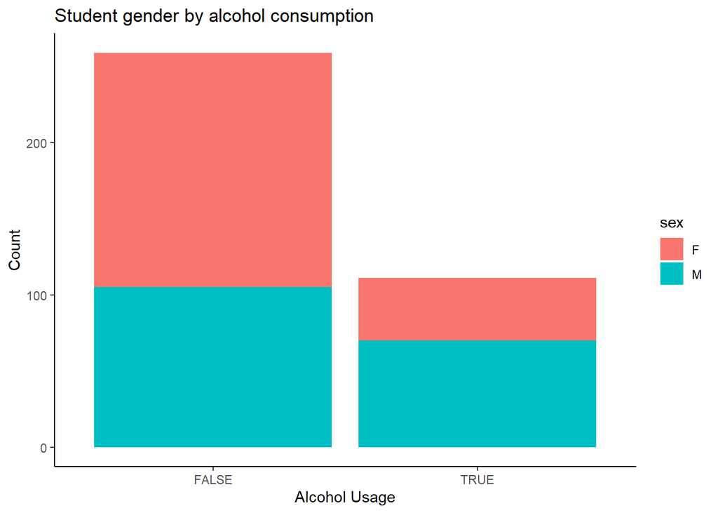

```r
g1 <- ggplot(alc, aes(high_use))
g1 + geom_bar(aes(fill = sex)) + ylab("Count") + xlab("Alcohol Usage") + ggtitle("Student gender by alcohol consumption") + theme_classic()
```

The majority of the people who consume high alcohol are males. The majority of the people who consume less alcohol are females.Looking at this, I think there may be a relationship between gender and the usage of alcohol, and males may have a higher consumption.

```r
# Romantic Relationship and Alcohol Usage

alc %>%
  group_by(romantic, high_use) %>%
  tally() %>%
  spread(high_use, n)
```

```
## # A tibble: 2 × 3
## # Groups:   romantic [2]
##   romantic `FALSE` `TRUE`
##   <chr>      <int>  <int>
## 1 no           173     78
## 2 yes           86     33
```

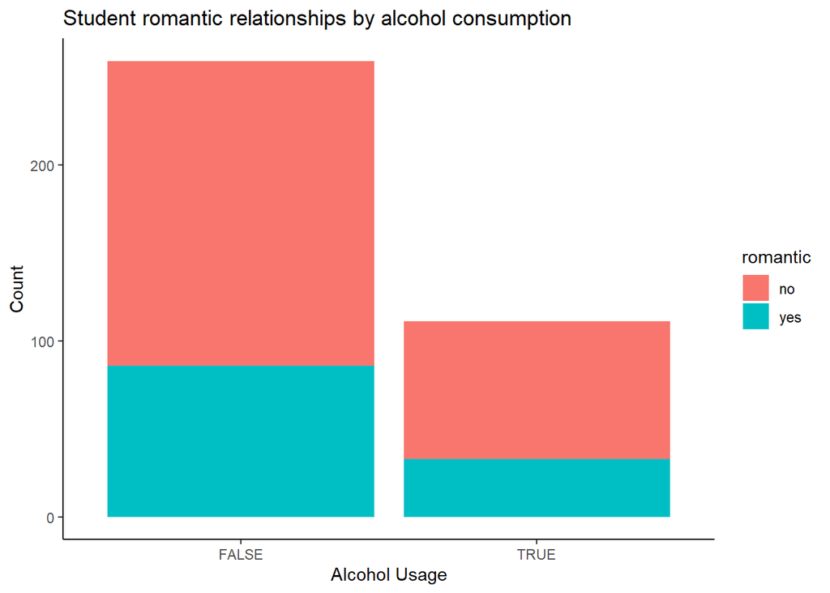

```r
g2 <- ggplot(alc, aes(high_use))
g2 + geom_bar(aes(fill = romantic)) + ylab("Count") + xlab("Alcohol Usage") + ggtitle("Student romantic relationships by alcohol consumption") + theme_classic()
```

The majority of the people who consume high alcohol are those who are not a romantic relationship. Similarly, the majority of the people who consume less alcohol also are those who are not a romantic relationship. Looking at this, there may be no any relationship between romantic relationship and the usage of alcohol.

```r
# Number of School Absences and Alcohol Usage

alc %>%
  group_by(high_use) %>%
  summarise(mean_absences = mean(absences))
```

```
## # A tibble: 2 × 2
##   high_use mean_absences
##   <lgl>            <dbl>
## 1 FALSE             3.71
## 2 TRUE              6.38
```

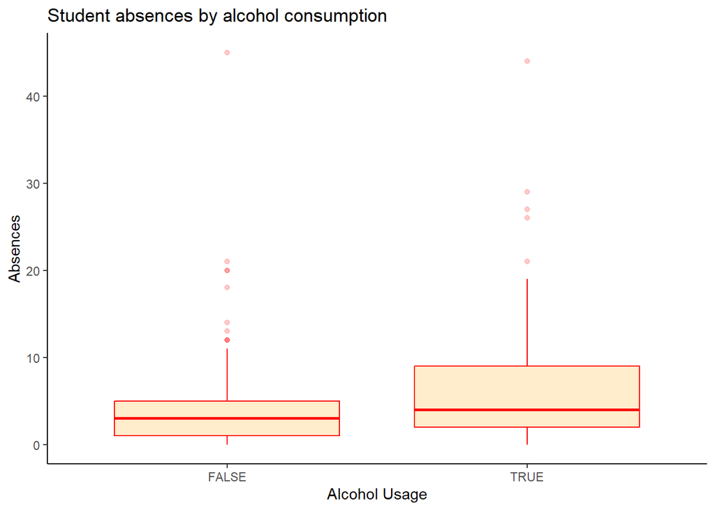

```r
g3 <- ggplot(alc, aes(x = high_use, y = absences))
g3 + geom_boxplot(color="red", fill="orange", alpha=0.2) + ylab("Absences") + xlab("Alcohol Usage") + ggtitle("Student absences by alcohol consumption") + theme_classic()
```

Compared to those who consume less alcohol, the ones who consume high alcohol tend to get more absences from their school. Thus, I think there may be a relationship between alcohol usage and the number of school absences, and those who get more absence may have high consumption of alcohol.

```r
# Number of School Absences and Alcohol Usage

alc %>%
  group_by(high_use) %>%
  summarise(mean_absences = mean(G3))
```

```
## # A tibble: 2 × 2
##   high_use mean_absences
##   <lgl>            <dbl>
## 1 FALSE             11.8
## 2 TRUE              10.9
```

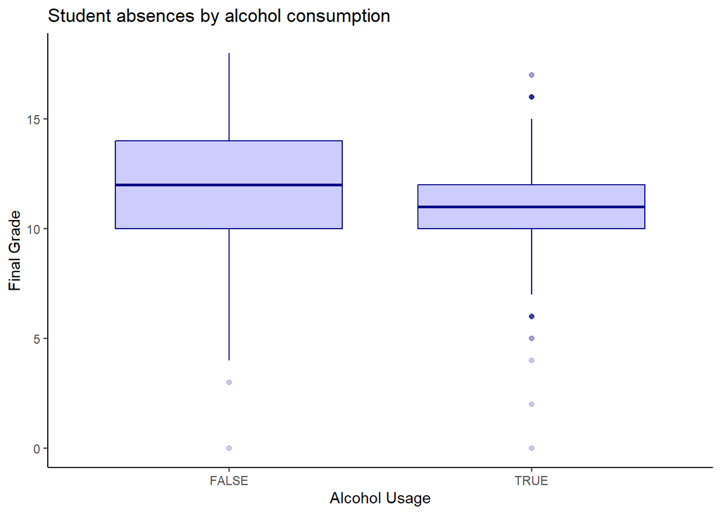

```r
g4 <- ggplot(alc, aes(x = high_use, y = G3))
g4 + geom_boxplot(color="darkblue", fill="blue", alpha=0.2) + ylab("Final Grade") + xlab("Alcohol Usage") + ggtitle("Student absences by alcohol consumption") + theme_classic()
```

Compared to those who consume less alcohol, the ones who consume high alcohol tend to get less results for their final exam. Thus, I think there may be a relationship between alcohol usage and the final grade of students, and those who score less grades may have high consumption of alcohol.

## Model Fitting and Interpretation

```r
Model <- glm(high_use ~ sex + romantic + absences + G3, data = alc, family = "binomial")

summary(Model)
```

```
##
## Call:
## glm(formula = high_use ~ sex + romantic + absences + G3, family = "binomial",
##     data = alc)
##
## Deviance Residuals:
##     Min       1Q   Median       3Q      Max
## -2.1950  -0.8506  -0.6125   1.0695   2.1557
##
## Coefficients:
##             Estimate Std. Error z value Pr(>|z|)
## (Intercept) -0.80786    0.48828  -1.654   0.0980 .
## sexM         1.02891    0.24635   4.177 2.96e-05 ***
## romanticyes -0.27725    0.26621  -1.041   0.2977
## absences     0.09402    0.02332   4.032 5.54e-05 ***
## G3          -0.08309    0.03702  -2.244   0.0248 *
## ---
## Signif. codes:  0 '***' 0.001 '**' 0.01 '*' 0.05 '.' 0.1 ' ' 1
##
## (Dispersion parameter for binomial family taken to be 1)
##
##     Null deviance: 452.04  on 369  degrees of freedom
## Residual deviance: 409.87  on 365  degrees of freedom
## AIC: 419.87
##
## Number of Fisher Scoring iterations: 4
```

```r
OR <- coef(Model) %>% exp

CI <- confint(Model) %>% exp
cbind(OR, CI)
```

```
##                    OR     2.5 %    97.5 %
## (Intercept) 0.4458116 0.1689959 1.1530093
## sexM        2.7980165 1.7371345 4.5719807
## romanticyes 0.7578671 0.4453847 1.2680721
## absences    1.0985786 1.0517733 1.1526939
## G3          0.9202643 0.8550404 0.9891028
```

Except for the romantic relationships (variable: romantic), all the other variables: gender (sex), number of school absences (absences) and final grade (G3) are significant factors to the usage of alcohol.

Regarding the coefficients of the model,

Sex: After adjusting for all the confounders, the odd ratio of male is exp(1.02891) = 2.7980165, with 95% Confidence Interval being 1.7371345 to 4.5719807. This means that the odds of usage of alcohol for males are 179% more likely as compared to females.

Romantic: This appeared to be an insignificant variable to the model.

Absences: After adjusting for all the confounders, the odd ratio of absences is exp(0.09402) = 1.0985786, with 95% Confidence Interval being 1.0517733 to 1.1526939. This means that the odds of usage of alcohol increases by about 9% for every 1 unit increase in the number of absences.

Earlier I thought that all the selected variable would have a significant relationship with the usage of alcohol. But it was proven that the romantic relationship is an insignificant factor to the alcohol usage. However all the other variables were significant, similar to what I thought before.

## Predictive power of the model

### Computation of Predictions

```r
ModelN <- glm(high_use ~ sex + absences + G3, data = alc, family = "binomial")

probabilities <- predict(ModelN, type = "response")

library(dplyr)

alc <- mutate(alc, probability = probabilities)

alc <- mutate(alc, prediction = probability > 0.5)

select(alc, G3, absences, sex, high_use, probability, prediction) %>% tail(10)
```

```
##     G3 absences sex high_use probability prediction
## 361 13        3   M    FALSE   0.3438727      FALSE
## 362  0        0   M    FALSE   0.5253210       TRUE
## 363  2        7   M     TRUE   0.6434944       TRUE
## 364 12        1   F    FALSE   0.1422811      FALSE
## 365  8        6   F    FALSE   0.2651901      FALSE
## 366  5        2   F    FALSE   0.2400651      FALSE
## 367 12        2   F    FALSE   0.1539348      FALSE
## 368  4        3   F    FALSE   0.2726742      FALSE
## 369 13        4   M     TRUE   0.3650114      FALSE
## 370 10        2   M     TRUE   0.3770647      FALSE
```

```r
table(high_use = alc$high_use, prediction = alc$prediction)
```

```
##         prediction
## high_use FALSE TRUE
##    FALSE   248   11
##    TRUE     83   28
```

In order to find the predictive power of the model, the insignificant variable: romantic relationship was removed from the model. A total of 276 cases was correctly predicted by the model. However, a total of 94 cases was incorrectly predicted by the model. The model resulted in 248 true negatives, 28 true positives, 83 false negatives and 11 false positives.

### Visualization of predictions

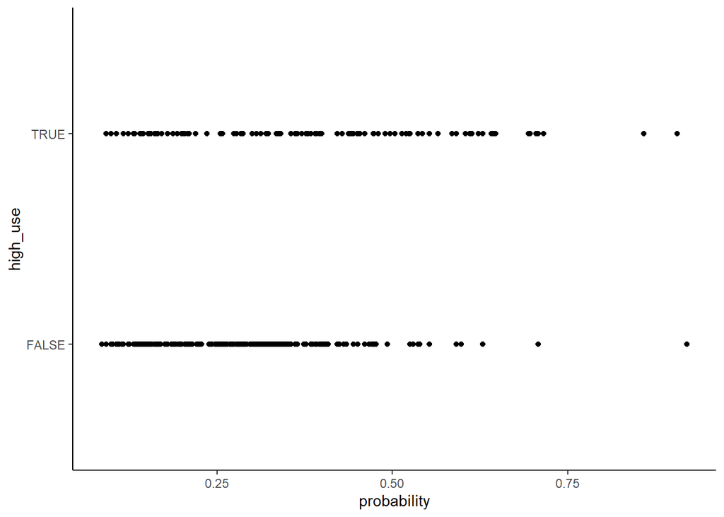

```r
library(dplyr); library(ggplot2)

g5 <- ggplot(alc, aes(x = probability, y = high_use))
g5 + geom_point() + theme_classic()
```

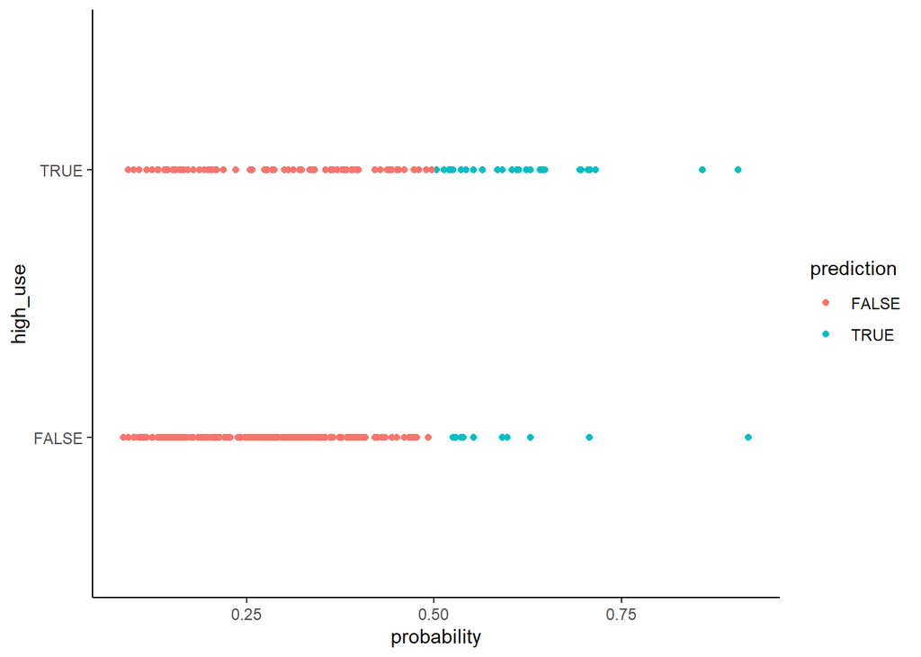

```r
g6 <- ggplot(alc, aes(x = probability, y = high_use, col = prediction))
g6 + geom_point() + theme_classic()
```

### Computation of probabilities and margins of predictions

```r
# Target variable versus the predictions
table(high_use = alc$high_use, prediction = alc$prediction)
```

```
##         prediction
## high_use FALSE TRUE
##    FALSE   248   11
##    TRUE     83   28
```

```r
# Target variable versus the probabilities of predictions
table(high_use = alc$high_use, prediction = alc$prediction) %>% prop.table()
```

```
##         prediction
## high_use      FALSE       TRUE
##    FALSE 0.67027027 0.02972973
##    TRUE  0.22432432 0.07567568
```

```r
#Add all margin totals
table(high_use = alc$high_use, prediction = alc$prediction) %>% prop.table() %>% addmargins()
```

```
##         prediction
## high_use      FALSE       TRUE        Sum
##    FALSE 0.67027027 0.02972973 0.70000000
##    TRUE  0.22432432 0.07567568 0.30000000
##    Sum   0.89459459 0.10540541 1.00000000
```

67% of the false high alcohol usage were correctly predicted while 3% of false high alcohol usage were incorrectly predicted as true. On the other hand, only 8% of the true high alcohol usage were correctly predicted while 22% of true high alcohol usage were incorrectly predicted as false.

### Accuracy and loss functions

```r
# define a loss function (mean prediction error)
loss_func <- function(class, prob) {
  n_wrong <- abs(class - prob) > 0.5
  mean(n_wrong)
}

# call loss_func to compute the average number of wrong predictions in the (training) data
loss_func(class = alc$high_use, prob = 0)
```

```
## [1] 0.3
```

```r
loss_func(class = alc$high_use, prob = 1)
```

```
## [1] 0.7
```

```r
loss_func(class = alc$high_use, prob = alc$probability)
```

```
## [1] 0.2540541
```

Total proportion of inaccurately classified individuals or the training error of this model is 25%. Only a one fourth of the cases were inaccurately classified, while three fourth of them were accurately classified. Overall, the performance of this model is good enough for further purposes.